# Practical Machine Learning Project

Manuel A. Bolivar

Monday, June 15, 2015

This document presents the application of a machine learning algorithm to predict the activity quality of an exercise using accelerometry data. The source of the data is: http://groupware.les.inf.puc-rio.br/har

## Data

The data is composed of 160 variables and 19622 observations. Each variable refers to a measure took by an accelerometer at the time that 6 of participants were performing a weight lifting excercise with different qualities (A,B,C,D,E).

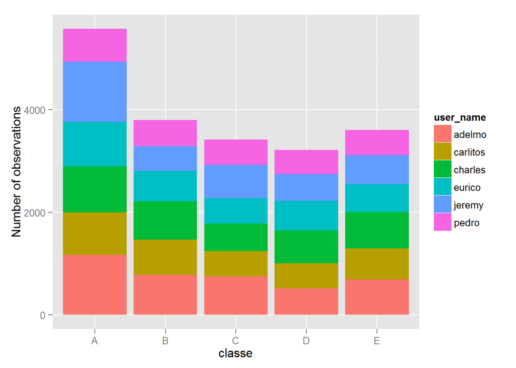

# Methods

The tidy data was divided into a training and testing data sets with $60\%$ and $40\%$ of the orginal data, respectively.

```r
#Divide data set
set.seed(123)
testobs <- createDataPartition(acdata$classe,p = .4,list = F)
test <- acdata[testobs,]
train <- acdata[-testobs,]
```

A different set of algorithms where implemented to predict the activity quality of the excercise, in this case, Random Forest, Linear Discriminant Analysis, and Quadratic Discriminant Analysis. Random Forest obtained better results so I’m going to explain how was their parameters selected.

Initially, I decided to use cross validation to choose an adecuated number of variables to randomly sample as candidates at each split in each tree (`mtry` parameter). Using the estimated of the test error within the training set, I select the adecuated parameters. To perform this procedure I used the `train` function in the caret package. Finally, it is important to notice that the number of trees used in the random forest is 25 (`ntree= 25`) because we need to take into account that if the number of trees is higher the computational time also increases but not the accuracy as seen in the following figure.

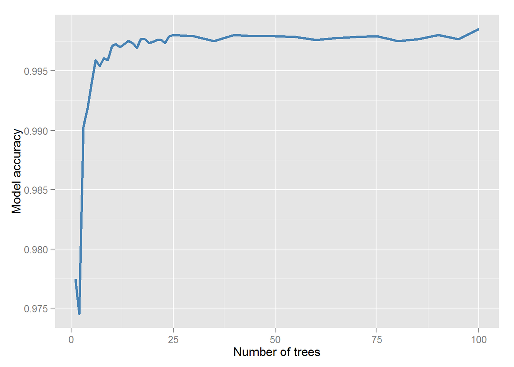

```r
fitControl <- trainControl(## 10-fold CV
  method = "cv",
  number = 10,)

mf_rf25 <- train(train$classe ~ .,method = "rf",ntree = 25,data=train,
                    trControl=fitControl)
mf_rf25
```

```
## Random Forest
##
## 11772 samples
##    55 predictor
##     5 classes: 'A', 'B', 'C', 'D', 'E'
##
## No pre-processing
## Resampling: Cross-Validated (10 fold)
##
## Summary of sample sizes: 10594, 10595, 10595, 10596, 10594, 10595, ...
##
## Resampling results across tuning parameters:
##
##   mtry  Accuracy   Kappa      Accuracy SD  Kappa SD
##    2    0.9924391  0.9904347  0.003385888  0.004283702
##   28    0.9971112  0.9963460  0.001341474  0.001696888
##   55    0.9959230  0.9948427  0.002327703  0.002944714
##
## Accuracy was used to select the optimal model using  the largest value.
## The final value used for the model was mtry = 28.
```

As the reader may appreciate in the previos output the number of variables chose randomly to split the tree is 28 out of 55 at each node with an test estimated error rate of $0.003$. This parameter was selected using the accuracy of the model computed as the sum of the test error obtained through 10 cross validation folds. The following code chunk presents the performance of the algorithm within the training set.

```r
mf_rf25$finalModel
```

```
##
## Call:
##  randomForest(x = x, y = y, ntree = 25, mtry = param$mtry)
##                Type of random forest: classification
##                      Number of trees: 25
## No. of variables tried at each split: 28
##
##         OOB estimate of  error rate: 0.24%
## Confusion matrix:
##      A    B    C    D    E  class.error
## A 3347    1    0    0    0 0.0002986858
## B    5 2270    3    0    0 0.0035118525
## C    0    5 2046    2    0 0.0034096444
## D    0    0    8 1921    0 0.0041472265
## E    0    1    0    3 2160 0.0018484288
```

To obtain an unbiased estimate of the out-of-sample error I run the model over the testing set and obtained the following results.

```r
pred_rf <- predict(mf_rf25,newdata=test)
confusionMatrix(test$classe,pred_rf)
```

```
## Confusion Matrix and Statistics
##
##           Reference
## Prediction    A    B    C    D    E
##          A 2232    0    0    0    0
##          B    1 1517    1    0    0
##          C    0    1 1368    0    0
##          D    0    0    3 1284    0
##          E    0    0    0    4 1439
##
## Overall Statistics
##
##                Accuracy : 0.9987
##                  95% CI : (0.9977, 0.9994)
##     No Information Rate : 0.2845
##     P-Value [Acc > NIR] : < 2.2e-16
##
##                   Kappa : 0.9984
##  Mcnemar's Test P-Value : NA
##
## Statistics by Class:
##
##                      Class: A Class: B Class: C Class: D Class: E
## Sensitivity            0.9996   0.9993   0.9971   0.9969   1.0000
## Specificity            1.0000   0.9997   0.9998   0.9995   0.9994
## Pos Pred Value         1.0000   0.9987   0.9993   0.9977   0.9972
## Neg Pred Value         0.9998   0.9998   0.9994   0.9994   1.0000
## Prevalence             0.2845   0.1934   0.1748   0.1641   0.1833
## Detection Rate         0.2843   0.1932   0.1743   0.1636   0.1833
## Detection Prevalence   0.2843   0.1935   0.1744   0.1639   0.1838
## Balanced Accuracy      0.9998   0.9995   0.9985   0.9982   0.9997
```

For this model the out of sample error is 0.001. Taking this into account I can say that the model provides a good performace in the task of predicting the activity quality on new information.

These are the results over the validation data set:

```r
pred_rf <- predict(mf_rf25,newdata=validation)
pred_rf
```

```
##  [1] B A B A A E D B A A B C B A E E A B B B
## Levels: A B C D E
```

## Conclusion

I used an machine learning algorithm to predict the activity quality of exercise using accelerometry data. I found that using weak predictors as trees and combining them using random forest provides good performance in this data set compare to other models like linear and quadratic discriminant analysis (LDA and QDA, respectively). As future work, it would interesting if an approach like random forest is applied to methods like LDA or QDA.